# Subset Selection

Applied Machine Learning in Economics

We could manually run each regression, compute the performance statistic, and the store all of the results, but I am feeling pretty confident that you guys can figure out how to do that (if not, give it a go!). Let’s just use a package.

# 1 Setup

```r
library(tidyverse) # Because, of course
library(leaps)     # subset selection
library(caret)     # cross-validation
ahs = read.csv('C:/Users/johnj/Documents/Data/Applied ML ECON490/Lecture Data/lecture data continuous.csv')
```

# 2 Subset selection

We will do all three types of subset selection: best subset selection, backward stepwise selection, and forward stepwise selection.

## 2.1 Best Subset Selection

Not gonna lie, I am a little intimidated for this section. Hopefully our computers can handle it! Remember that best subset selection computes $2^p$ models, where $p$ is the number of parameters we have.

To do best subsets, we will use the `regsubsets()` function from `leaps`. You input the full model, just like `lm()`.

```r
#log(value) ~ log(cost):hoa + npeople + log(hinc) + beds + baths + log(eqvval) + lotsize + yos + condo + garage + I(bld == 'Mobile Home') + poly(math, 2) - hoa
system.time(
  {
    best_fits = regsubsets(log(value) ~ log(cost)*hoa + npeople + beds*baths + log(eqvval) + lotsize + yos + garage + bld + poly(math, 2) + crime + hinf + houtf, ahs, nvmax = Inf)
  }
)
```

```
##    user  system elapsed
##    0.02    0.00    0.02
```

```r
summary(best_fits)
```

```
## Subset selection object
## Call: regsubsets.formula(log(value) ~ log(cost) * hoa + npeople + beds *
##     baths + log(eqvval) + lotsize + yos + garage + bld + poly(math,
##     2) + crime + hinf + houtf, ahs, nvmax = Inf)
## 20 Variables  (and intercept)
##                   Forced in Forced out
## log(cost)             FALSE      FALSE
## hoaTRUE               FALSE      FALSE
## npeople               FALSE      FALSE
## beds                  FALSE      FALSE
## baths                 FALSE      FALSE
## log(eqvval)           FALSE      FALSE
## lotsize               FALSE      FALSE
## yos                   FALSE      FALSE
## garageTRUE            FALSE      FALSE
```

[output cut: 97 more lines]

Is anyone else not bothered by the fact that we just ran a million models in less than a second? Perhaps because our dataset is a small one. Be cautious when applying to larger dataset.

So, which model should we choose? Since humans are visual creatures… yada, yada, yada… We will select our model using BIC (see recording) because it tends to favor parsimonious models. When using information criterions, we want the smallest value. How about some lazy plots/

```r
sbest = summary(best_fits)

min(sbest$bic); which.min(sbest$bic)
```

```
## [1] -4426.798
```

```
## [1] 9
```

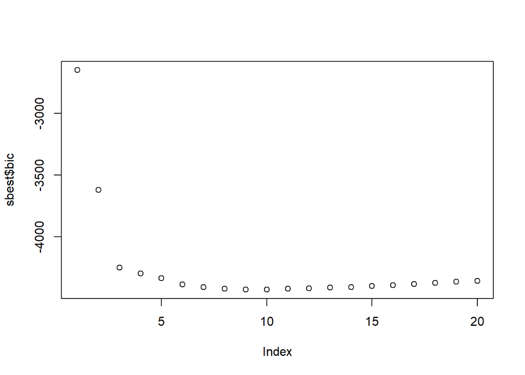

```r
plot(sbest$bic)
```

Well, the best BIC is the model with 9 parameters. However, according to this figure the kink is at 3 parameters. Let’s obtain those models.

```r
coef(best_fits, 3)
```

```
##    (Intercept)      log(cost)    log(eqvval) bldMobile Home
##      1.0079230      0.5264127      0.6056691     -1.5241794
```

```r
coef(best_fits, 9)
```

```
##    (Intercept)      log(cost)           beds    log(eqvval)        lotsize
##     3.08864112     0.49441763     0.06921970     0.39413720     0.02585858
##            yos     garageTRUE bldMobile Home poly(math, 2)1 poly(math, 2)2
##     0.03143983     0.13884747    -1.48474805     4.40404985   -12.77342229
```

Because we are always concerned with fitting irreducible noise, I would suggest choosing the model with only three parameters. However, we can be more confident with our selections in the cross-validation section.

## 2.2 Backward Stepwise Selection

I wonder what model we will select this time!

```r
back_fits = regsubsets(log(value) ~ log(cost)*hoa + npeople + beds*baths + log(eqvval) + lotsize + yos + garage + bld + poly(math, 2) + crime + hinf + houtf, ahs, nvmax = Inf, method = 'backward')

sback = summary(back_fits)

min(sback$bic); which.min(sback$bic)
```

```
## [1] -4426.798
```

```
## [1] 9
```

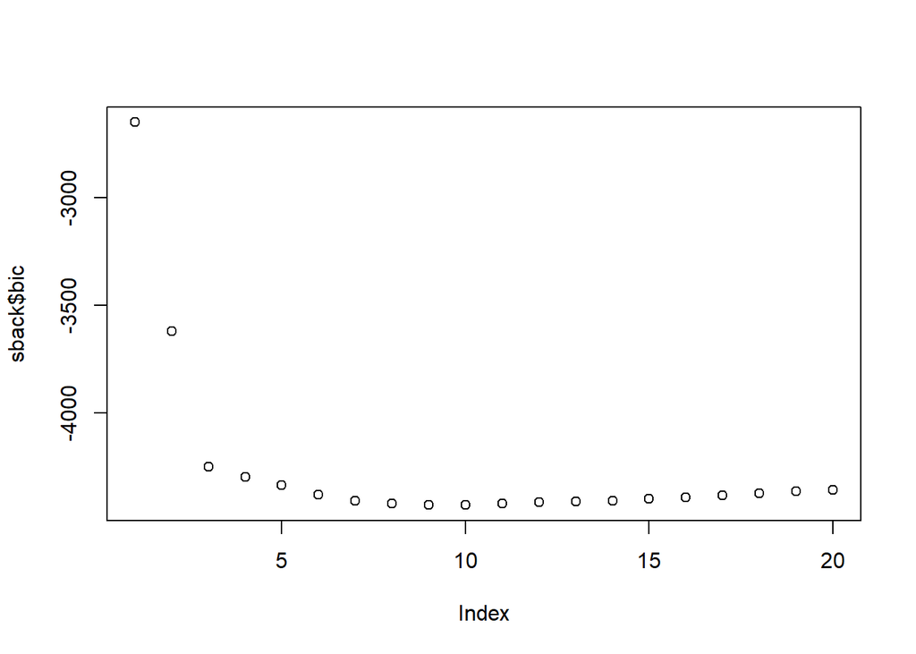

```r
plot(sback$bic)
```

Based upon the output, it looks like we selected the same model. Let’s see if that is true.

```r
coef(back_fits, 3)
```

```
##    (Intercept)      log(cost)    log(eqvval) bldMobile Home
##      1.0079230      0.5264127      0.6056691     -1.5241794
```

```r
coef(back_fits, 9)
```

```
##    (Intercept)      log(cost)           beds    log(eqvval)        lotsize
##     3.08864112     0.49441763     0.06921970     0.39413720     0.02585858
##            yos     garageTRUE bldMobile Home poly(math, 2)1 poly(math, 2)2
##     0.03143983     0.13884747    -1.48474805     4.40404985   -12.77342229
```

We ended up with the same models!

## 2.3 Forward Stepwise Selection

```r
forw_fits = regsubsets(log(value) ~ log(cost)*hoa + npeople + beds*baths + log(eqvval) + lotsize + yos + garage + bld + poly(math, 2) + crime + hinf + houtf, ahs, nvmax = Inf, method = 'forward')

sforw = summary(forw_fits)

min(sforw$bic); which.min(sforw$bic)
```

```
## [1] -4424.881
```

```
## [1] 10
```

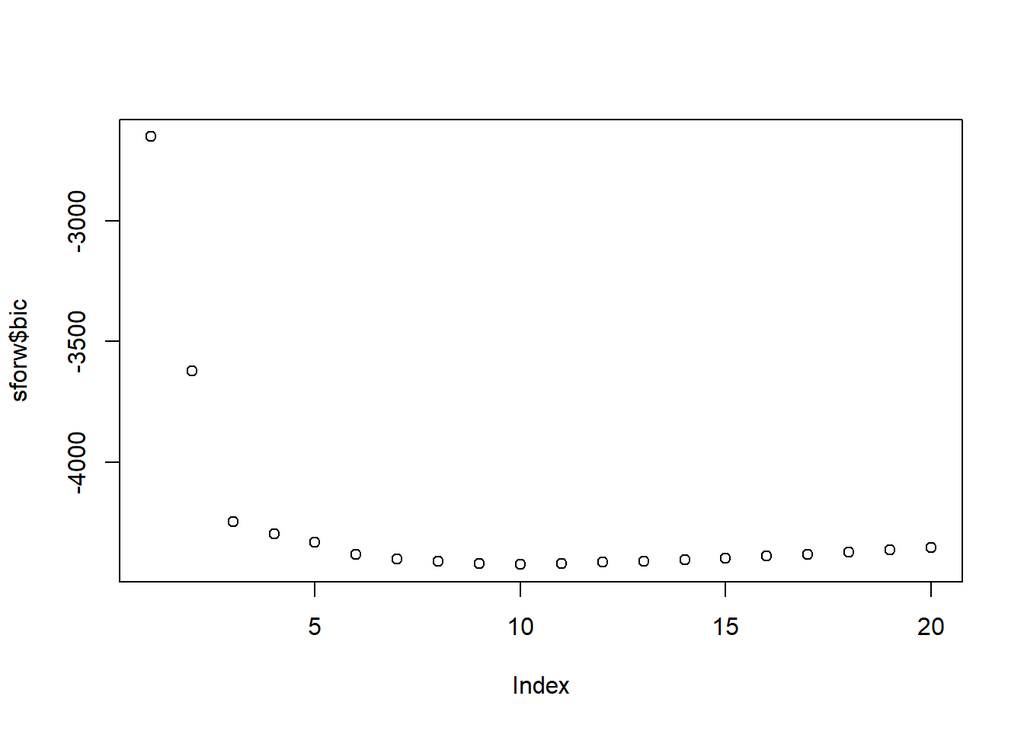

```r
plot(sforw$bic)
```

Few! I was worried I wasn’t going to be able to showcase that these techniques do select different models.

```r
coef(forw_fits, 3)
```

```
##    (Intercept)      log(cost)    log(eqvval) bldMobile Home
##      1.0079230      0.5264127      0.6056691     -1.5241794
```

```r
coef(forw_fits, 10)
```

```
##     (Intercept)       log(cost)            beds     log(eqvval)         lotsize
##      2.98785502      0.49619754      0.05494131      0.40027982      0.02311712
##             yos      garageTRUE bldDetached SFH  bldMobile Home  poly(math, 2)1
##      0.03226082      0.12251767      0.07344288     -1.43054216      4.21110269
##  poly(math, 2)2
##    -12.73105616
```

It looks like the forward selection method prefers the addition of detached single-family homes!

## 2.4 Discussion

In general, there is no reason for these techniques to select the same model. It looks like *effectively* did here because some variables are **very** important predictors, and others don’t influence a thing! That means when we start from either an empty model or the full model, we more or less have a ranking of parameters that are important predictors. You can think about this as lining up people from age 1 to 16 (one per age) by height.

# 3 Cross-Validation

`caret` is an incredibly useful package. [Here](https://topepo.github.io/caret/available-models.html) is a list of the available models that we can cross-validate.

Since fitting a million models didn’t take that long, let’s boldly try to do 5 repeated 4-fold cross-validation of the best-subset selection.

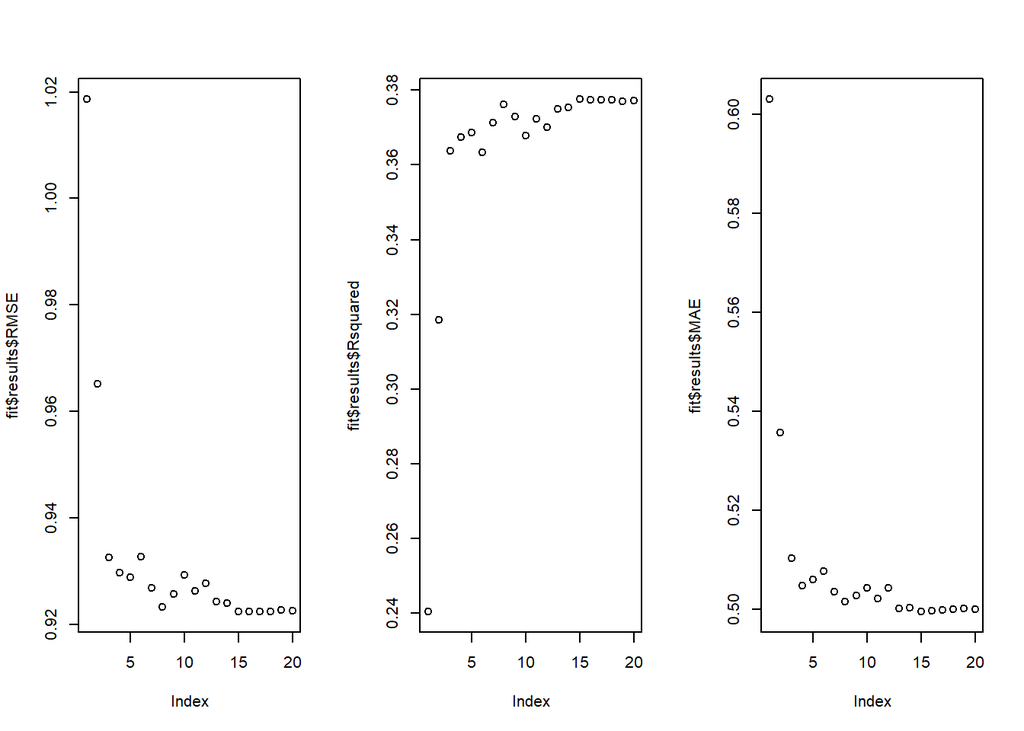

```r
trControl = trainControl(method = 'repeatedcv',
                         number = 4,
                         repeats = 5)


fit = train(log(value) ~ log(cost)*hoa + npeople + beds*baths + log(eqvval) + lotsize + yos + garage + bld + poly(math, 2) + crime + hinf + houtf,
            method = 'leapSeq', # the caret version of regsubset. It is outdated
            trControl = trControl,
            tuneGrid = expand.grid(nvmax = 1:20),
            data = ahs)

par(mfrow = c(1,3))
plot(fit$results$RMSE)
plot(fit$results$Rsquared)
plot(fit$results$MAE)
```

```r
fit$bestTune
```

```
##    nvmax
## 15    15
```

The CV tells us the best subset selection model is the one with 15 parameters. However, this is still quite large. Based upon these figures, I would choose the model with 7 parameters. Yes, this is a bit subjective.